# Datarock Data Challenge

- Show All Code
- Hide All Code
- View Source

Author

Matt Clauson

Published

October 7, 2024

# Introduction

Investigate data and screen models for classification.

```r
library(tidyverse)
library(here)
library(visdat)
library(dlookr)
library(robCompositions)
library(brms)
library(cmdstanr)
library(rsample)

## ggplot theme
theme_mc <- function(base_size = 20) {
    theme_bw(base_size = base_size) %+replace%
        theme(
            # margins
            plot.title = element_text(size = rel(1), face = "bold", margin = margin(0, 0, 5, 0), hjust = 0),
            # grids
            panel.grid.minor = element_blank(),
            panel.border = element_blank(),
            # axes
            axis.title = element_text(size = rel(0.75), face = "bold"),
            axis.text = element_text(size = rel(0.60), face = "bold"),
            axis.line = element_line(color = "black", arrow = arrow(length = unit(0.3, "lines"), type = "closed")),
            # Legend
            legend.title = element_text(size = rel(0.75), face = "bold"),
            legend.text = element_text(size = rel(0.60), face = "bold"),
            legend.key = element_rect(fill = "transparent", colour = NA),
            legend.key.size = unit(1.5, "lines"),
            legend.background = element_rect(fill = "transparent", colour = NA),
            legend.position = "bottom",
            # facets
            strip.background = element_rect(fill = "#17252D", color = "#17252D"),
            strip.text = element_text(size = rel(0.75), face = "bold", color = "white", margin = margin(5, 0, 5, 0))
        )
}

theme_set(theme_mc())

# functions
# deal with "<" in Au
convert_and_replace <- function(x) {
  # find rows that have "<"
  if_else(grepl("<", x),
          as.numeric(sub("<", "", x)) / 2,  # strip character, divide by two
          as.numeric(x))                     # else convert to numeric
}

# CoDA PCA

perform_codapca <- function(data, additional_data = NULL, pca_method = "robust") {
  # Perform PCA
  pca_result <- pcaCoDa(data, method = pca_method)

  summary_result <- summary(pca_result)

  # Extract scores from PCA
  scores <- as.data.frame(pca_result$scores)
  scores$id <- rownames(scores)

  # If there is additional data to bind, bind it
  if (!is.null(additional_data)) {
    scores <- scores %>% bind_cols(additional_data)
  }

  # Extract loadings
  loadings <- as.data.frame(pca_result$loadings)
  loading_labels <- rownames(loadings)
  loadings <- cbind(Feature = loading_labels, loadings)

  # Return scores and loadings as separate data frames
  return(list(summary_result, scores = scores, loadings = loadings))
}

# plot biplot

plot_biplot_var <- function(score_df, loading_df, colour_var, pc_x, pc_y, scaling_var = 4){

  # Ensure the PC columns exist in the data frames
  pc_x_col <- paste0("PC", pc_x)
  pc_y_col <- paste0("PC", pc_y)

  if(!(pc_x_col %in% names(score_df)) | !(pc_y_col %in% names(score_df))){
    stop("Specified principal components are not found in the scores data frame.")
  }

  if(!(pc_x_col %in% names(loading_df)) | !(pc_y_col %in% names(loading_df))){
    stop("Specified principal components are not found in the loadings data frame.")
  }

  # Combine score_df with the selected colour variable
  combined_df <- score_df %>%
    bind_cols(colour_var = class_df[[colour_var]])

  # Create the biplot
  ggplot(combined_df, aes_string(x = pc_x_col, y = pc_y_col)) +
    geom_point(aes_string(colour = "colour_var", alpha = 0.4)) +
    #scale_color_viridis_c() +  # Uncomment if you want to use viridis color scale
    geom_segment(
      data = loading_df,
      aes_string(
        x = 0,
        y = 0,
        xend = paste0(pc_x_col, " * ", scaling_var),
        yend = paste0(pc_y_col, " * ", scaling_var)
      ),
      arrow = arrow(
        length = unit(0.3, "cm"),
        type = "open",
        angle = 25
      ),
      size = 1,
      color = "darkblue"
    ) +
    ggrepel::geom_text_repel(data = loading_df, aes_string(x = paste0(pc_x_col, " * ", scaling_var), y = paste0(pc_y_col, " * ", scaling_var), label = "row.names(loading_df)")) +
    labs(title = "Log Ratio PCA | All", x = pc_x_col, y = pc_y_col)
}

set_cmdstan_path("C:\\Users\\mclauson\\cmdstan-2.34.1")
multi_metric <- yardstick::metric_set(yardstick::rsq, yardstick::mae, yardstick::rmse)
```

```r
data_for_distribution <- read_csv(here("data/data_for_distribution.csv"))
```

# Cleaning

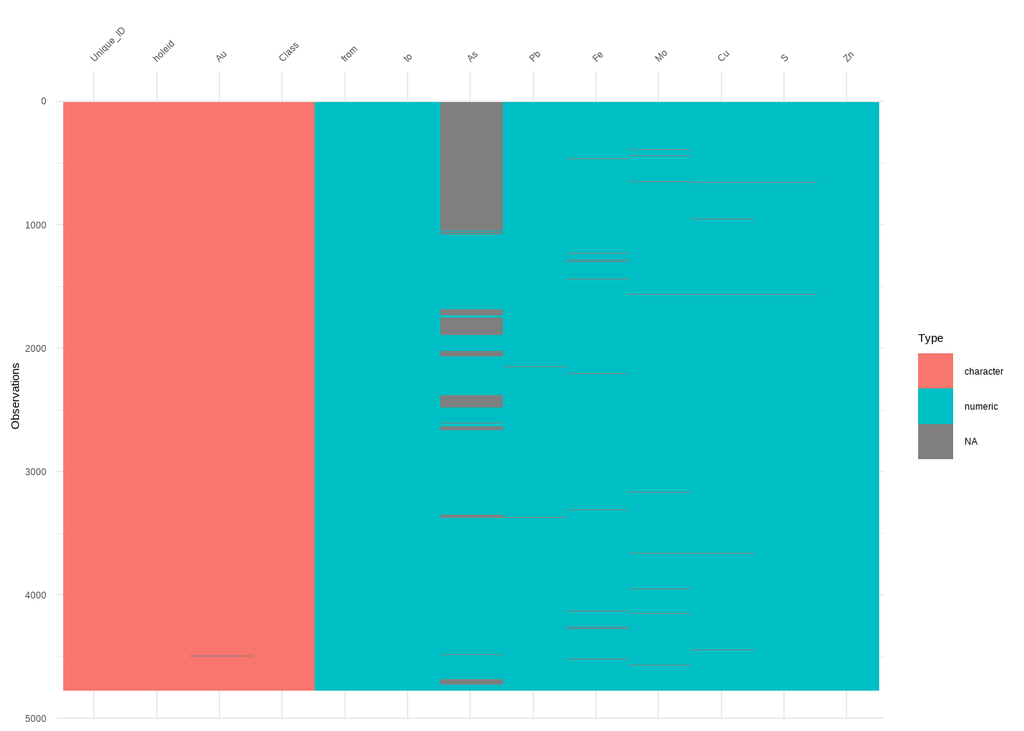

```r
vis_dat(data_for_distribution)
```

First thing, `Au` is character, `As` has large amount missing.

```r
df <- data_for_distribution %>%
  mutate(Au = as.numeric(Au))
```

Converting to numeric introduces NAs for `Au`, checking due to LOD (<), symbol needs to be dealt with.

Convert `Au` to numeric, and check for default values.

```r
df <- data_for_distribution %>%
  mutate(Au = convert_and_replace(Au))
```

Quick check for defaults e.g. -99. Can’t have negative values for assays.

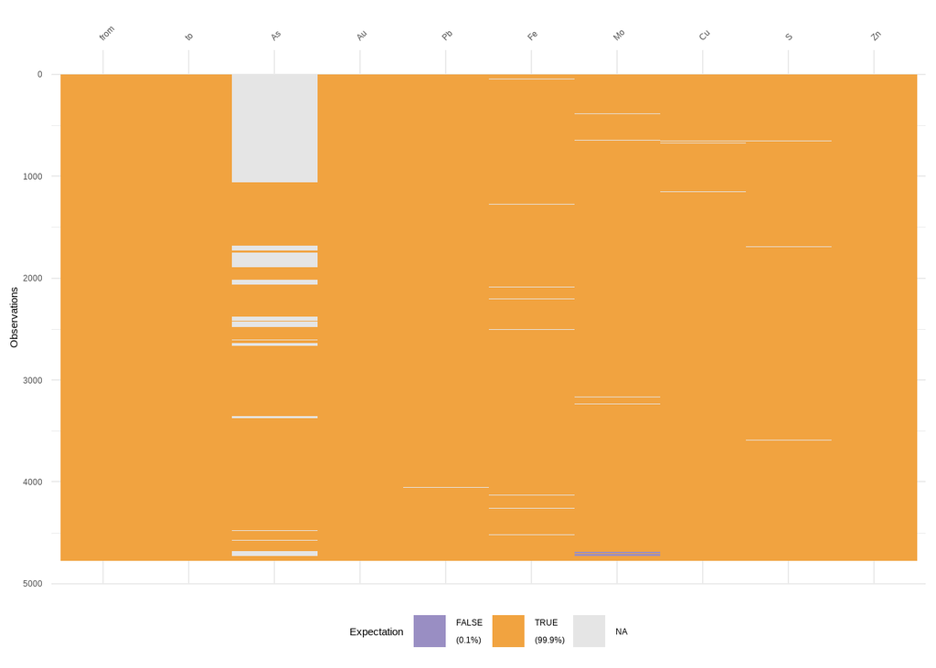

```r
vis_expect(df %>% select(where(is.numeric)), ~.x >= 0) # only interested in numeric (not strictly from/to)
```

Check compositing of the drill holes length.

```r
df %>%
  mutate(composite_length = to - from) %>%
  group_by(holeid) %>%
  summarise(
    mean_length = mean(composite_length),
    min_length = min(composite_length),
    max_length = max(composite_length)
  ) %>%
  filter(mean_length != 10)
```

```
# A tibble: 48 × 4
   holeid   mean_length min_length max_length
   <chr>          <dbl>      <dbl>      <dbl>
 1 SOLVE004        9.89       6.70         10
 2 SOLVE007        9.67       6            10
 3 SOLVE015        9.9        9.5          10
 4 SOLVE030        9.92       5.10         10
 5 SOLVE031        9.91       7.5          10
 6 SOLVE036        9.87       6.30         10
 7 SOLVE037        9.99       9.5          10
 8 SOLVE041        9.98       8.40         10
 9 SOLVE043        9.93       5.30         10
10 SOLVE044        9.94       5.30         10
# ℹ 38 more rows
```

Check for duplicate IDs.

```r
df %>%
  summarise(across(c(Unique_ID, holeid),
                   ~ n_distinct(.) / n() * 100,
                   .names = "percent_unique_{col}"))
```

```
# A tibble: 1 × 2
  percent_unique_Unique_ID percent_unique_holeid
                     <dbl>                 <dbl>
1                      100                  2.93
```

Check Classes.

```r
df %>%
  group_by(Class) %>%
  summarise(count = n(),
            count_pct = n() / nrow(df) * 100)
```

```
# A tibble: 3 × 3
  Class count count_pct
  <chr> <int>     <dbl>
1 ?       767      16.1
2 A      2861      60.0
3 B      1143      24.0
```

Missing class label for ~16% of the rows.

Replace default values and `?` with NA and view relationship to missing classes.

```r
df <- df %>%
  mutate(across(everything(), ~ ifelse(. == -999 | . == "?", NA, .)))
```

Check intersection of missingness.

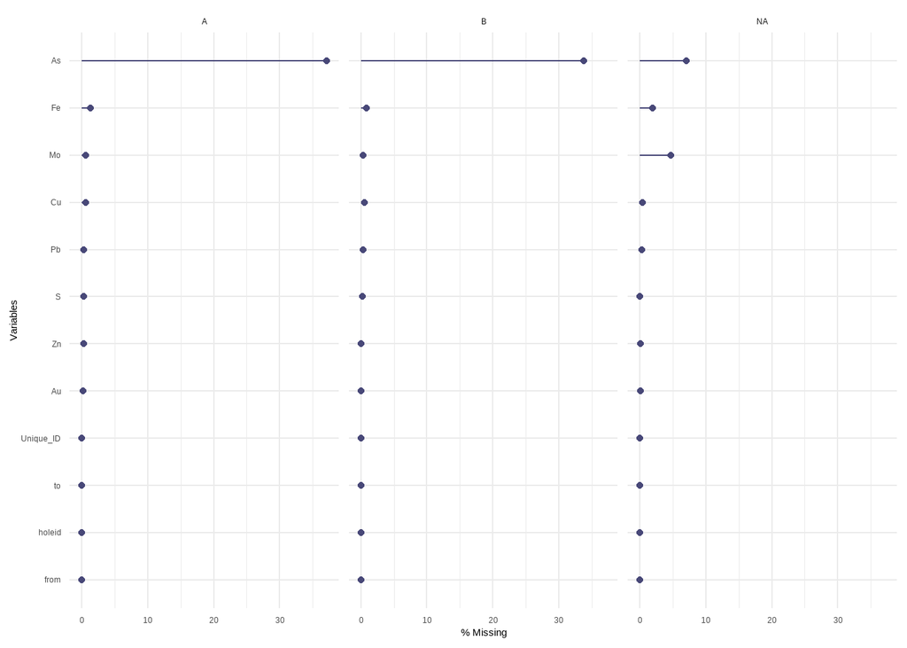

```r
naniar::gg_miss_var(df, show_pct = TRUE, facet = Class)
```

### Summary

- `from/to` & `sampleid` are complete.
- Replace LOD `Au` values with LOD/2 as a quick fix.
- Default values replaced with NA.
- `?` Class replaced with NA to make the missingness clearer.

# EDA

Check normality, distribution, PCA, CoDA.

Removal of `?` and other NA values.

Dropping the `?` Class rows as these can’t be used for training the model. Dropping NA from the assays as without more information struggling to justify imputing data or removal of column.

```r
df %>%
  select(As:Zn) %>%
  normality()
```

```
# A tibble: 8 × 4
  vars  statistic  p_value sample
  <chr>     <dbl>    <dbl>  <dbl>
1 As       0.400  6.77e-74   4771
2 Au       0.467  2.33e-80   4771
3 Pb       0.518  3.65e-78   4771
4 Fe       0.680  1.95e-69   4771
5 Mo       0.311  9.63e-86   4771
6 Cu       0.0424 1.93e-93   4771
7 S        0.607  6.49e-74   4771
8 Zn       0.229  1.57e-88   4771
```

```r
df %>%
  group_by(Class) %>%
  select(As:Zn) %>%
  describe() %>%
  select(described_variables:kurtosis,p25,p50,p75,p100)
```

```
# A tibble: 24 × 14
   described_variables Class     n    na       mean         sd   se_mean     IQR
   <chr>               <chr> <int> <int>      <dbl>      <dbl>     <dbl>   <dbl>
 1 As                  A      1799  1062    11.4       13.6      0.321   7.4 e+0
 2 As                  B       756   387    34.2       53.0      1.93    2.99e+1
 3 As                  <NA>    713    54    25.5       49.7      1.86    1.98e+1
 4 Au                  A      2856     5     0.0609     0.0849   0.00159 5.7 e-2
 5 Au                  B      1143     0     0.0294     0.0805   0.00238 2.2 e-2
 6 Au                  <NA>    766     1     0.0524     0.113    0.00407 5   e-2
 7 Cu                  A      2845    16    15.8      138.       2.59    6   e+0
 8 Cu                  B      1137     6     8.26      17.2      0.511   4.4 e+0
 9 Cu                  <NA>    764     3     6.19      15.5      0.561   2.8 e+0
10 Fe                  A      2824    37 49724.     14029.     264.      1.87e+4
# ℹ 14 more rows
# ℹ 6 more variables: skewness <dbl>, kurtosis <dbl>, p25 <dbl>, p50 <dbl>,
#   p75 <dbl>, p100 <dbl>
```

### Raincloud Plots

Check distribution of numeric variables.

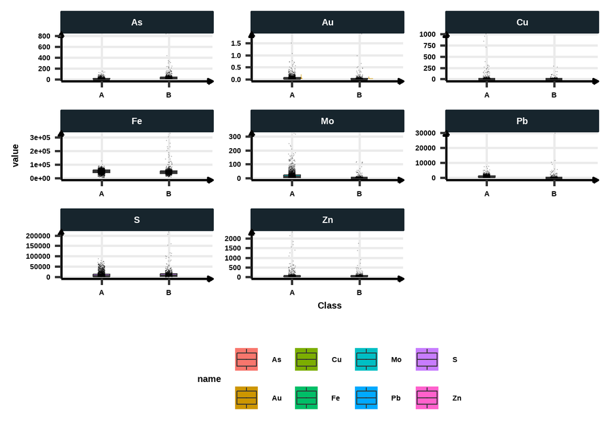

```r
n_df <- df %>% select(As:Zn, Class) %>% drop_na() %>% select(-Class) %>% data.frame()
class_df <- df %>% select(As:Zn, Class) %>% drop_na() %>% select(Class)

n_df %>%
  bind_cols(class_df) %>%
  pivot_longer(!Class) %>%
  #filter(name == "As") %>%
  ggplot(aes(x = Class, y = value, fill = name)) +
  ggdist::stat_halfeye(
    adjust = .1,
    width = .5,
    .width = 0,
    justification = -.3,
    point_colour = NA) +
  geom_boxplot(
    width = .25,
    outlier.shape = NA
  ) +
  geom_point(
    size = 0.1,
    alpha = .2,
    position = position_jitter(
      seed = 1, width = .05
    )
  ) +
  coord_cartesian(clip = "off") +
  facet_wrap(~name, scales = "free")
```

## CoDA PCA

- Plot shows strong zonation in the first two principal components.
- `Pb`, `Au`, `Mo` strongly correlated more associated with Class A.
- `Cu`, `Fe`, `Zn` are positively correlated, weaker positively correlated to `As` & negatively correlated to `Pb`, Au, Mo. Associated with Class B.
- `S` orthogonal to other elements, indicating no correlation also appears to have little relationship to Class.

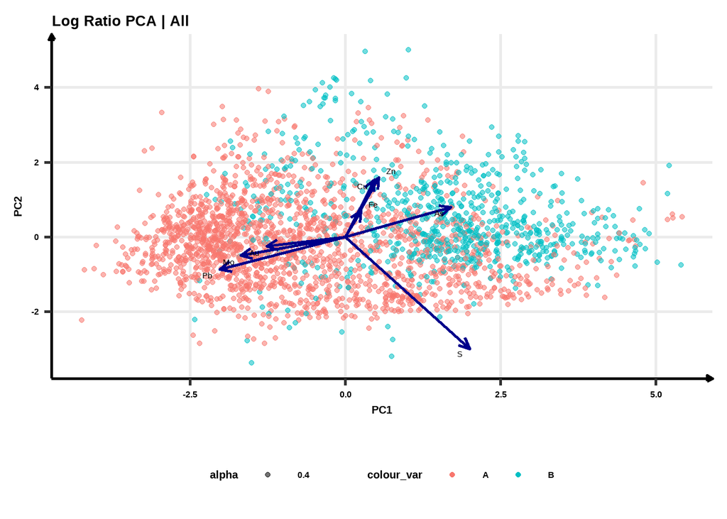

```r
out.pca <- ToolsForCoDa::lrpca(n_df)
Fp <- out.pca$Fp
Gs <- out.pca$Gs
decom <- out.pca$decom

scores_df <- as.data.frame(Fp)
loadings_df <- as.data.frame(Gs)
names(loadings_df) <- paste0("PC", 1:ncol(loadings_df))

plot_biplot_var(scores_df, loadings_df, "Class", 1,2, 4)
```

Rather than go down the ILR and single binary partition plots, going to use log-ratios of the elements.

## Log Ratio Analysis

The element `As` is only in one of the log-ratios, might be able to remove this column which would allow more data to be kept for training the model without affecting the overall model too much.

Otherwise curiously the `Fe` appears to be important.

```r
lr_res <- easyCODA::STEP(n_df)

ex_var <- lr_res$R2max
lr_selected <- lr_res$names

# print lr
print(lr_selected)
```

```
[1] "Fe/S"  "Pb/Fe" "Fe/Zn" "As/Mo" "Fe/Mo" "Fe/Cu" "Au/Fe"
```

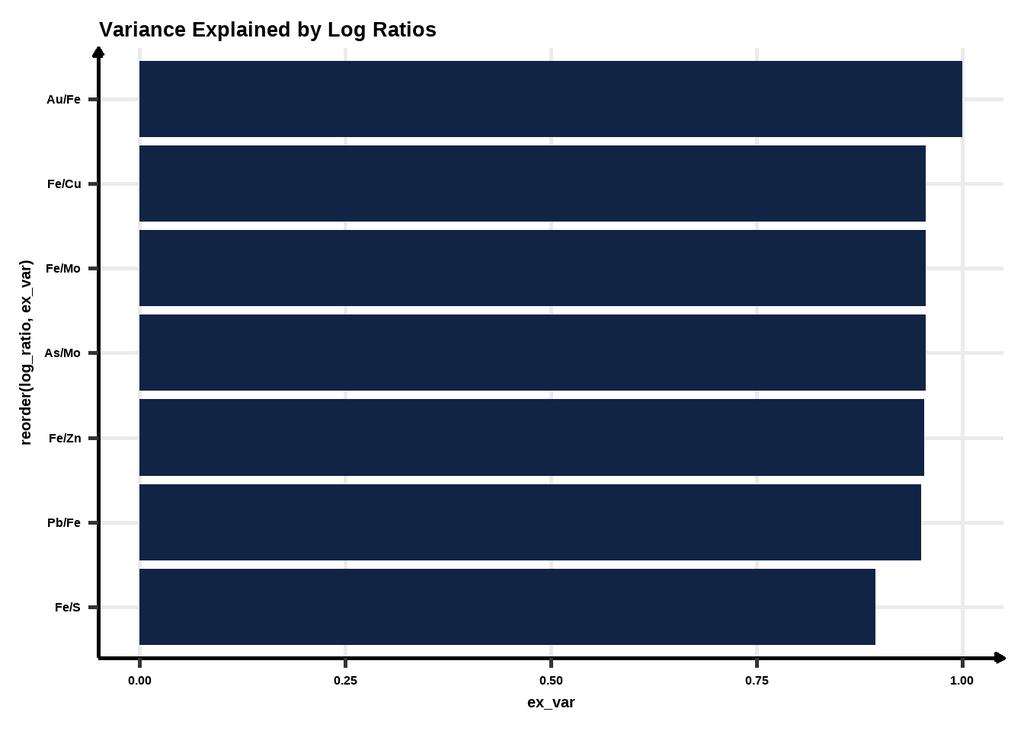

```r
# plot
var1 <- bind_cols(ex_var, lr_selected) %>%
  rename(ex_var = ...1, log_ratio = ...2)

ggplot(var1) +
  aes(x = ex_var, y = reorder(log_ratio, ex_var)) +
  geom_bar(stat = "summary", fun = "sum", fill = "#112446") +
  labs(title = "Variance Explained by Log Ratios")
```

# Classification

## Logistic

Trial log-ratio approach as data is compositional.

Use horseshoe prior to select variables.

```r
reg_df <- bind_cols(n_df, class_df)

lr_reg_df <- reg_df %>%
  mutate(fe_s = Fe/S, pb_fe = Pb/Fe, fe_zn = Fe/Zn, as_mo = As/Mo, fe_mo = Fe/Mo, fe_cu = Fe/Cu, au_fe = Au/Fe) %>%
  select(fe_s:au_fe, Class)

# split data

set.seed(123)
split <- initial_split(lr_reg_df, prop = 0.8)

# Extract training and testing sets
train_data <- training(split)
test_data <- testing(split)
```

```r
mod1_hs <- brm(
  Class ~ .,
  data = train_data,
  family = bernoulli(),
  prior = set_prior(horseshoe(1)),
  file_refit = "on_change",
  file = here("fits", "mod1_hs"),
  backend = "cmdstanr",
  iter = 2000,
  cores = 16,
  threads = threading(4),
  control = list(adapt_delta = 0.9, max_treedepth = 12)
)

print(mod1_hs)
```

```
 Family: bernoulli
  Links: mu = logit
Formula: Class ~ fe_s + pb_fe + fe_zn + as_mo + fe_mo + fe_cu + au_fe
   Data: train_data (Number of observations: 2001)
  Draws: 4 chains, each with iter = 2000; warmup = 1000; thin = 1;
         total post-warmup draws = 4000

Regression Coefficients:
          Estimate Est.Error l-95% CI u-95% CI Rhat Bulk_ESS Tail_ESS
Intercept    -0.36      0.17    -0.70    -0.04 1.01     1556     2910
fe_s          0.00      0.00    -0.00     0.00 1.05       52     1342
pb_fe       -41.07      6.49   -55.10   -28.75 1.03     2074     2574
fe_zn        -0.00      0.00    -0.00    -0.00 1.00     1093     1982
as_mo         0.06      0.01     0.05     0.08 1.02     2179     3158
fe_mo         0.00      0.00     0.00     0.00 1.00     2152     3119
fe_cu         0.00      0.00     0.00     0.00 1.01      458      968
au_fe        -0.01      0.31    -0.32     0.14 1.03      180      387

Draws were sampled using sample(hmc). For each parameter, Bulk_ESS
and Tail_ESS are effective sample size measures, and Rhat is the potential
scale reduction factor on split chains (at convergence, Rhat = 1).
```

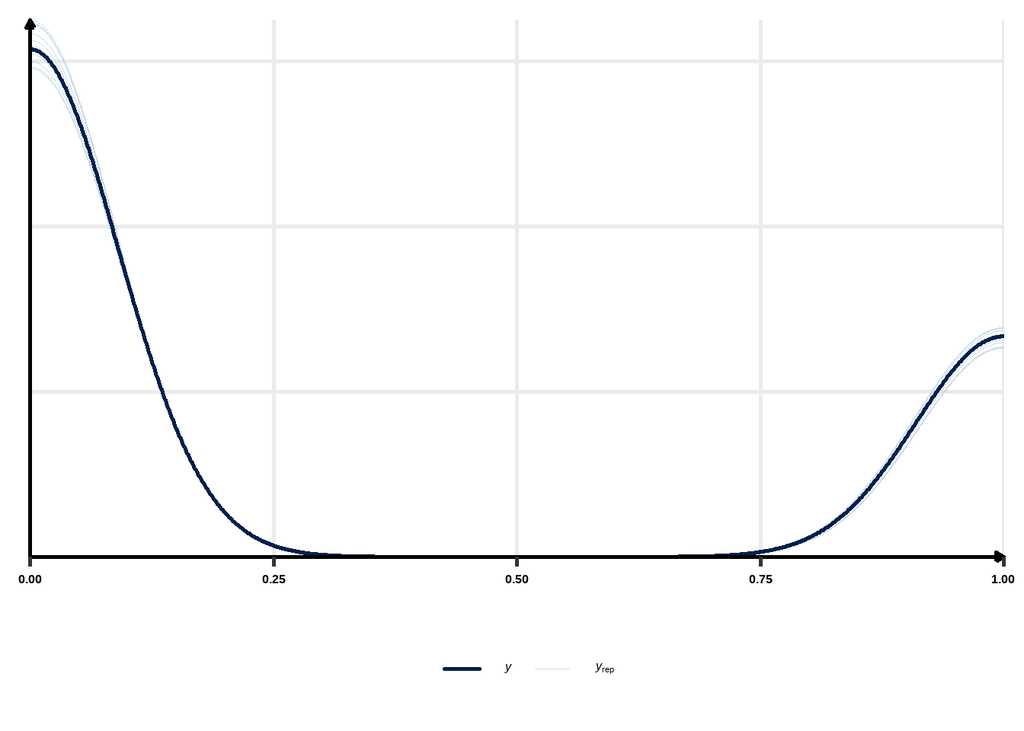

```r
# PP Check
pp_check(mod1_hs)
```

Refit model with reduced variables.

```r
# refit model
mod2_simple <- brm(
  Class ~ pb_fe + as_mo + au_fe,
  data = train_data,
  family = bernoulli(),
  file_refit = "on_change",
  file = here("fits", "mod2_simple"),
  backend = "cmdstanr",
  iter = 2000,
  cores = 16,
  threads = threading(4),
  control = list(adapt_delta = 0.9, max_treedepth = 12)
)

print(mod2_simple)
```

```
 Family: bernoulli
  Links: mu = logit
Formula: Class ~ pb_fe + as_mo + au_fe
   Data: train_data (Number of observations: 2001)
  Draws: 4 chains, each with iter = 2000; warmup = 1000; thin = 1;
         total post-warmup draws = 4000

Regression Coefficients:
            Estimate Est.Error   l-95% CI   u-95% CI Rhat Bulk_ESS Tail_ESS
Intercept      -0.78      0.11      -0.99      -0.57 1.00     3662     3339
pb_fe         -43.04      7.11     -56.69     -29.43 1.00     2309     2578
as_mo           0.08      0.01       0.07       0.10 1.00     3051     3066
au_fe     -357862.57  77424.20 -518622.77 -215236.23 1.00     2393     2366

Draws were sampled using sample(hmc). For each parameter, Bulk_ESS
and Tail_ESS are effective sample size measures, and Rhat is the potential
scale reduction factor on split chains (at convergence, Rhat = 1).
```

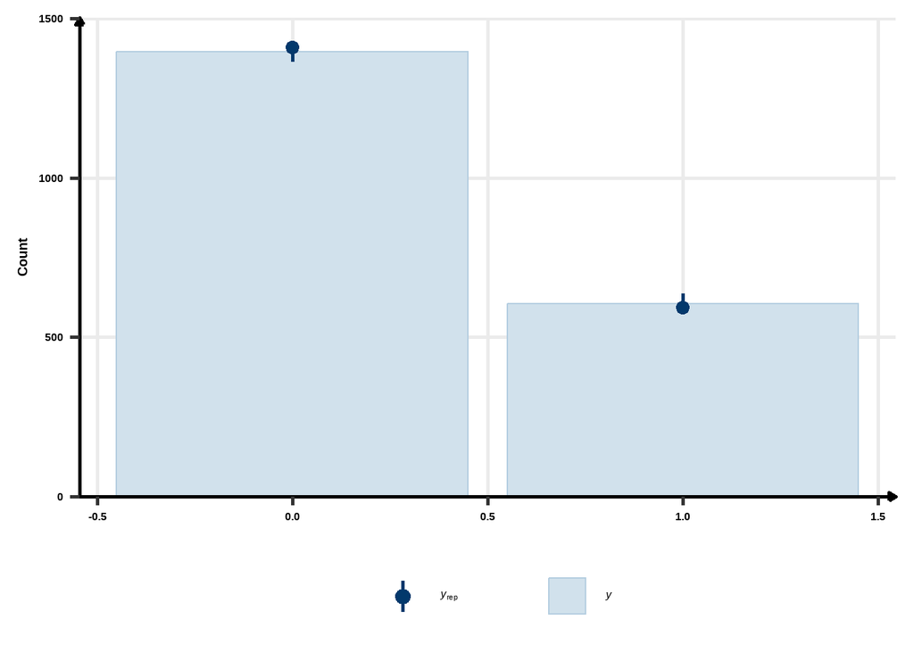

```r
pp_check(mod2_simple, type = "bars")
```

```r
predicted_probs <- broom.mixed::augment(mod2_simple, newdata = test_data)

augmented_test_data <- predicted_probs %>%
  mutate(
    predicted_class = ifelse(.fitted > 0.5, 1, 0),
    Class_num = if_else(Class == "A", 0, 1),
    f_pred = as.factor(predicted_class),
    f_actual = as.factor(Class_num)
  )

# Step 2: Confusion matrix and F1 score calculation
# Confusion Matrix
conf_mat <- yardstick::conf_mat(augmented_test_data, truth = f_actual, estimate = f_pred)

# F1 Score
f1 <- yardstick::f_meas(augmented_test_data, truth = f_actual, estimate = f_pred)

# Output the confusion matrix and F1 score
print(conf_mat)
```

```
          Truth
Prediction   0   1
         0 336  66
         1  28  71
```

```r
print(f1)
```

```
# A tibble: 1 × 3
  .metric .estimator .estimate
  <chr>   <chr>          <dbl>
1 f_meas  binary         0.877
```

f score is okay, looks like might be suffering from class imbalance which might be helped with SMOTE etc.

## Black Box

Screen many models to assess if classification is viable.

```r
library(tidymodels)
library(bestNormalize)
library(baguette)
library(discrim)
library(embed)
library(themis)

lr_reg_df <- reg_df %>%
  mutate(fe_s = Fe/S, pb_fe = Pb/Fe, fe_zn = Fe/Zn, as_mo = As/Mo, fe_mo = Fe/Mo, fe_cu = Fe/Cu, au_fe = Au/Fe) %>%
  mutate(Class = as.factor(Class))

# split data

set.seed(123)
split <- initial_validation_split(lr_reg_df, prop = c(0.75, 0.125), strata = Class)

# Extract training and testing sets
train_data <- training(split)
test_data <- testing(split)
valid_data <- vfold_cv(lr_reg_df)
```

```r
rec <- recipe(Class ~ ., data = train_data) %>%
  step_zv(all_numeric_predictors()) %>%
  step_orderNorm(all_numeric_predictors()) %>%
  step_normalize(all_numeric_predictors()) %>%
  # try using SMOTE
  step_smote(Class)

mlp_spec <-
  mlp(hidden_units = tune(), penalty = tune(), epochs = tune()) %>%
  set_engine('nnet') %>%
  set_mode('classification')

bagging_spec <-
  bag_tree() %>%
  set_engine('rpart') %>%
  set_mode('classification')

fda_spec <-
  discrim_flexible(
    prod_degree = tune()
  ) %>%
  set_engine('earth')

rda_spec <-
  discrim_regularized(frac_common_cov = tune(), frac_identity = tune()) %>%
  set_engine('klaR')

bayes_spec <-
  naive_Bayes() %>%
  set_engine('klaR')

pls_rec <-
  rec %>%
  step_pls(all_numeric_predictors(), outcome = "Class", num_comp = tune())

pca_rec <-
  rec %>%
  step_pca(all_numeric_predictors(), num_comp = tune())
```

```r
ctrl <- control_grid(parallel_over = "everything")

res <-
  workflow_set(
    preproc = list(basic = Class ~., pls = pls_rec, pca = pca_rec),
    models = list(bayes = bayes_spec, fda = fda_spec,
                  rda = rda_spec, bag = bagging_spec,
                  mlp = mlp_spec)
  ) %>%
  workflow_map(
    verbose = TRUE,
    seed = 199,
    resamples = valid_data,
    grid = 10,
    metrics = metric_set(f_meas),
    control = ctrl
  )
```

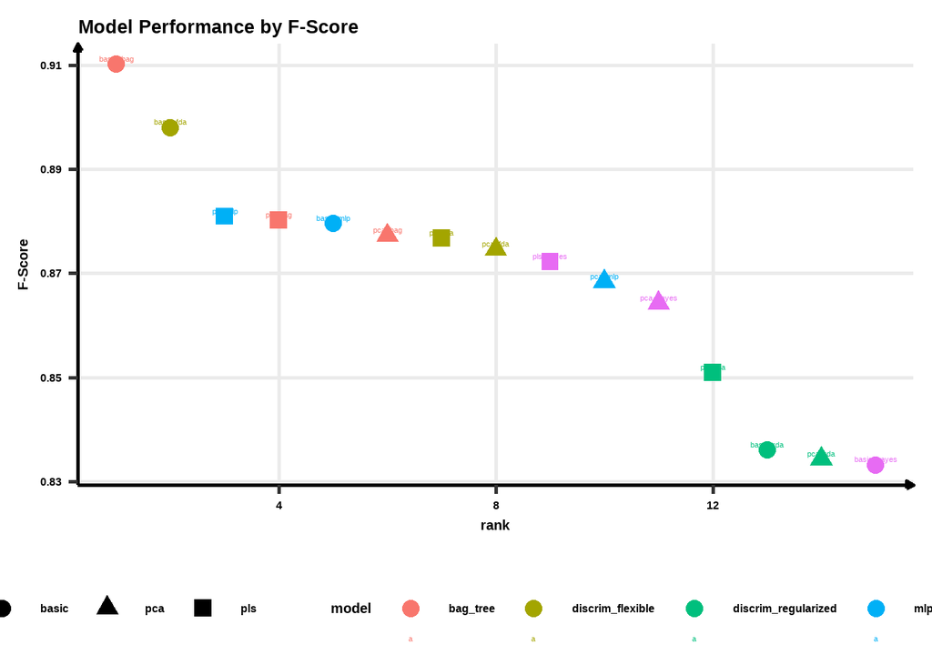

```r
rankings <-
  rank_results(res, select_best = TRUE) %>%
  mutate(method = map_chr(wflow_id, ~ str_split(.x, "_", simplify = TRUE)[1]))

ggplot(rankings, aes(x = rank, y = mean, color = model, shape = method)) +
  geom_point(size = 4) +  # Add points
  geom_text(aes(label = wflow_id), vjust = -0.5, size = 3) +  # Add labels
  labs(x = "rank", y = "F-Score", title = "Model Performance by F-Score")
```

Bagged tree classifies quite well but could be overfitting? Interestingly, dimension reduction techniques don’t appear to be helpful for this problem.

# Conclusion

Classification of the A & B zones seems possible with varying performance achieved by different model types. Further background information would provide context around what variables to use and potential inclusion of spatial information.

# Appendix

Further analysis of principal components.

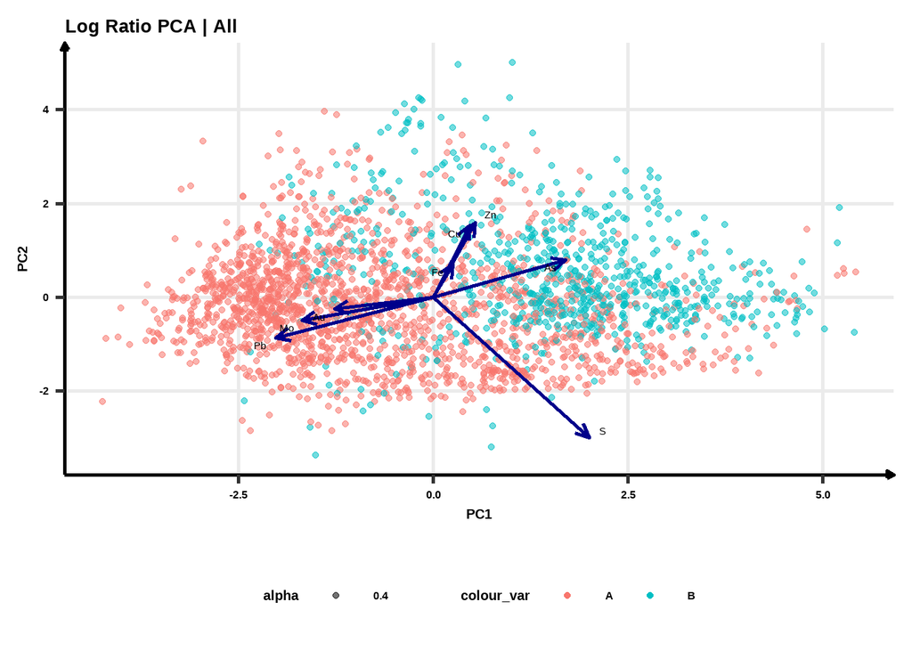

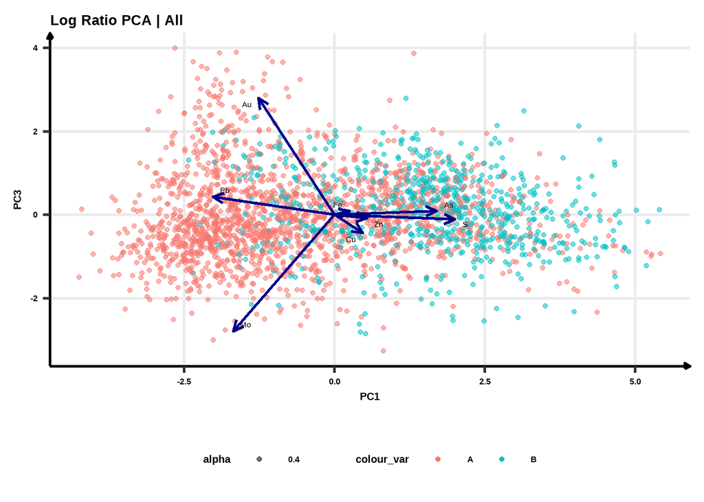

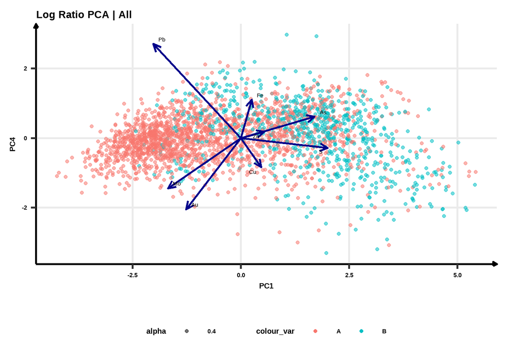

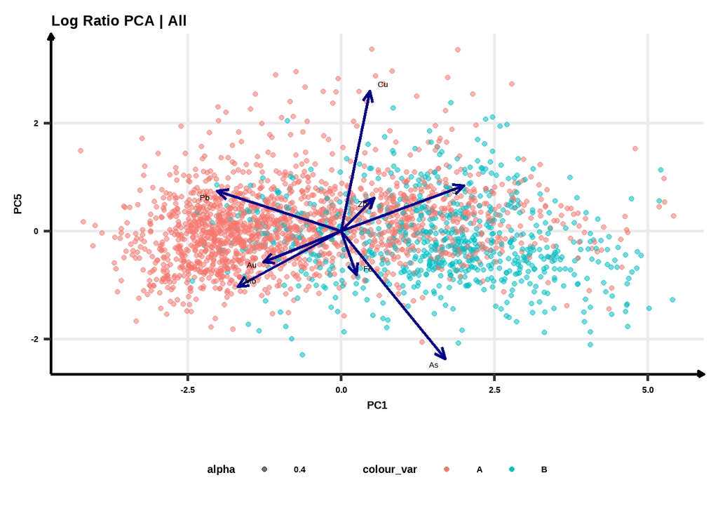

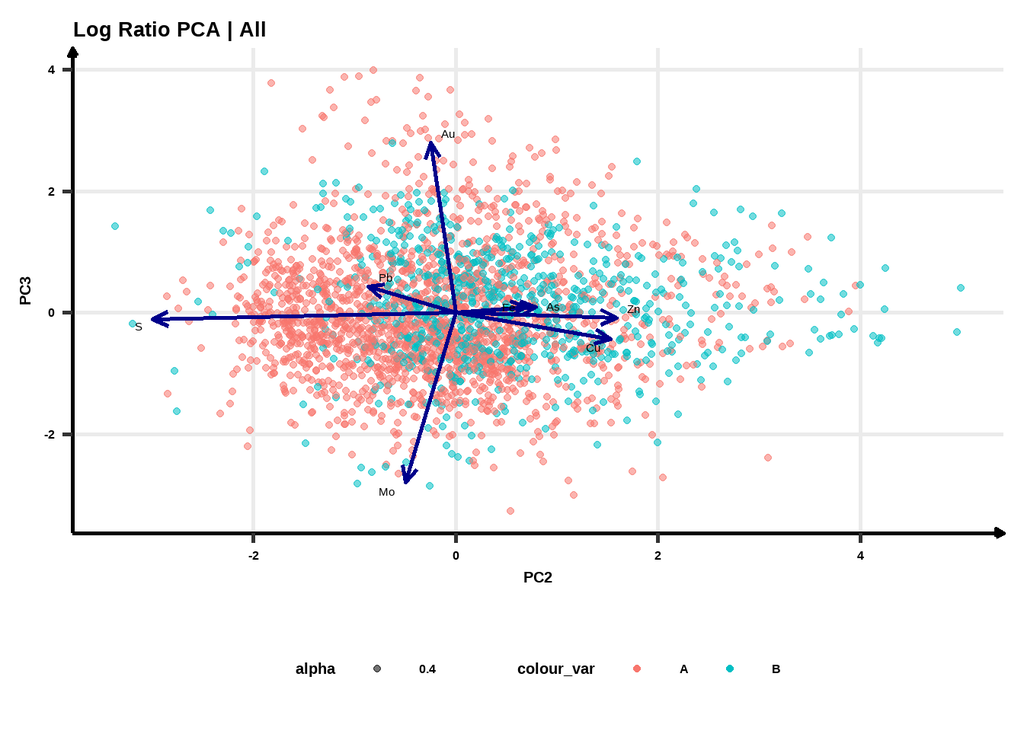

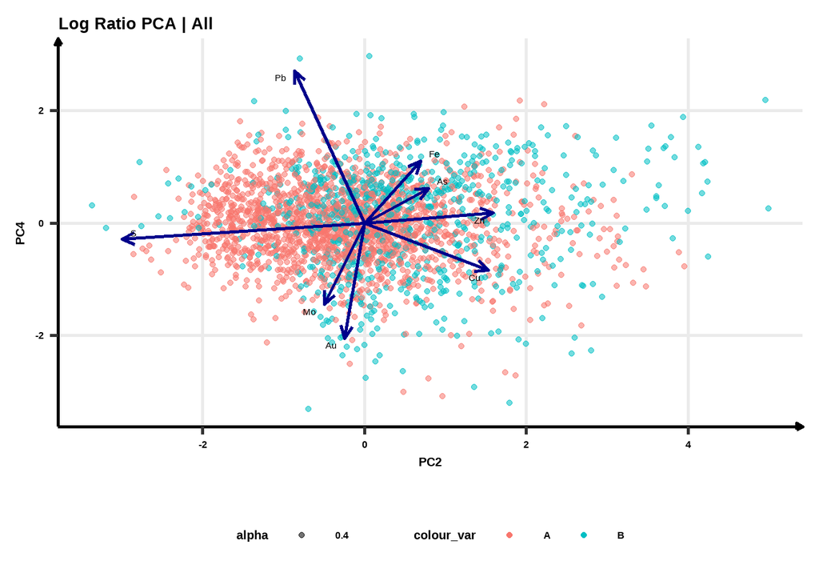

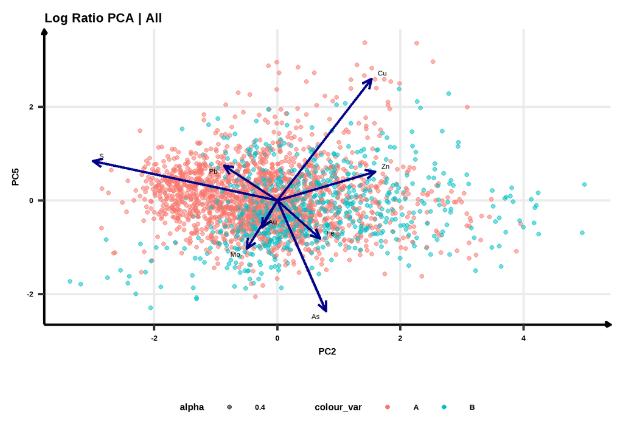

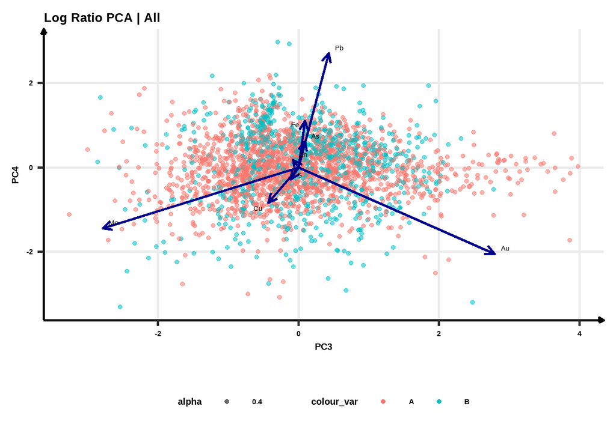

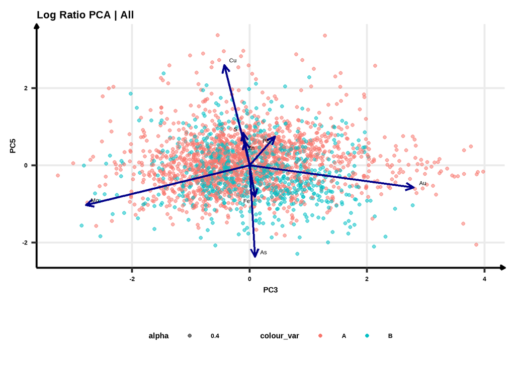

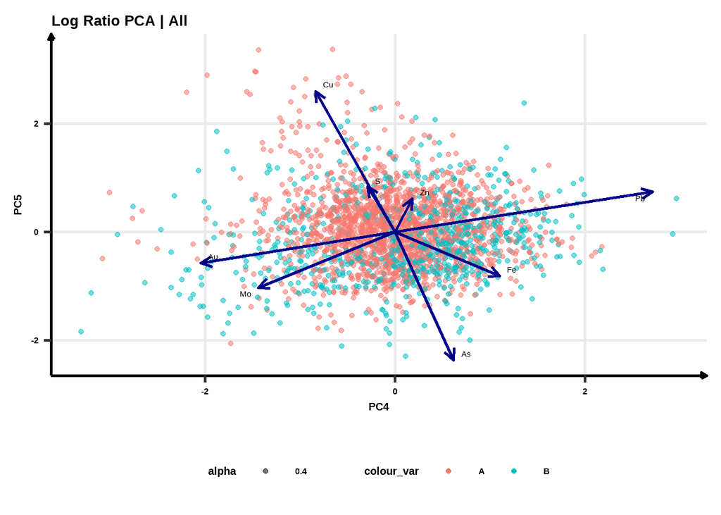

```r
for (i in 1:4) {
  for (j in (i + 1):5) {
    # Call the plot_biplot_var function for each pair
    plot <- plot_biplot_var(scores_df, loadings_df, "Class", i, j, scaling_var = 4)

    # Save or display the plot
    print(plot)

    # can save here
    # ggsave(paste0("biplot_PC", i, "_PC", j, ".png"), plot)
  }
}
```